# Análise Exploratória sobre Mortalidade por Psicoativos no Brasil e no Espírito Santo

### 5.1. Mapas

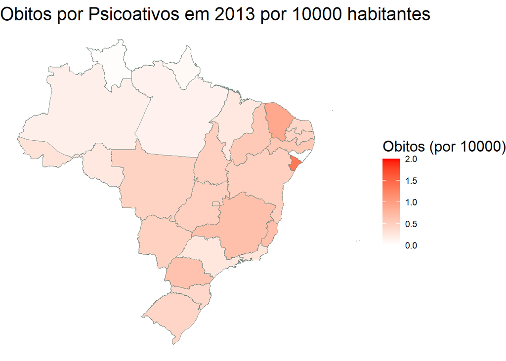

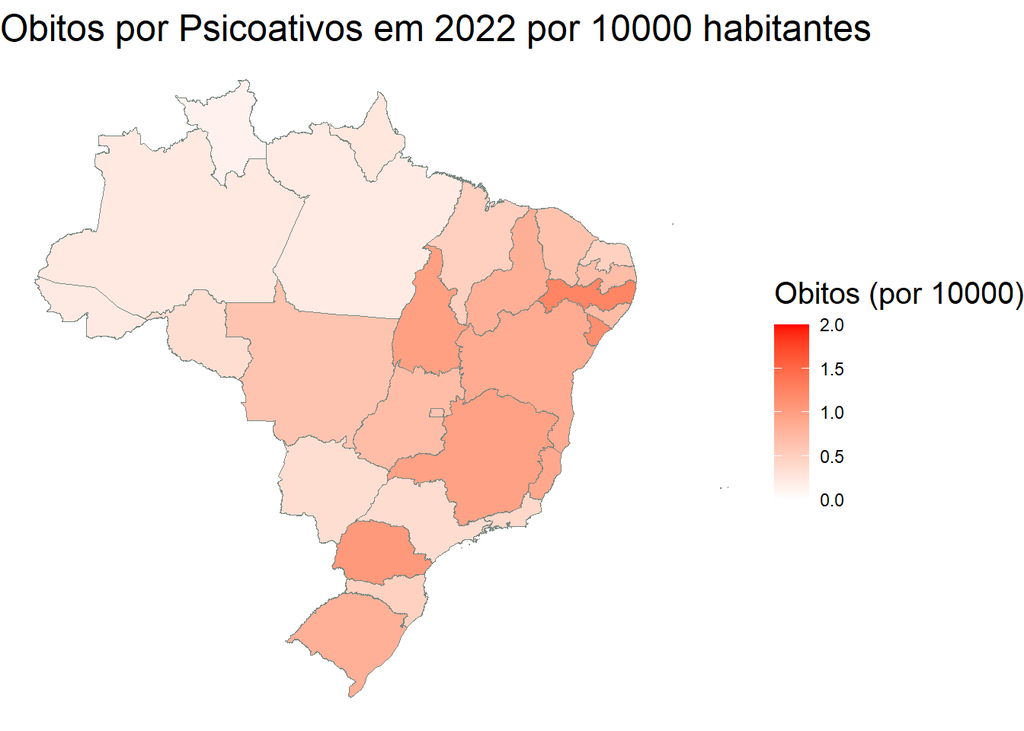

### 5.2. Gráfico de calor

Através do gráfico de calor é possível ter uma ideia geral do número de mortes por psicoativos a cada 100 mil habitantes em todos os estados do Brasil e no país, tudo isso no decorrer de 10 anos. O estado do Sergipe é o com maior número de ocorrência a cada 100 mil habitantes.

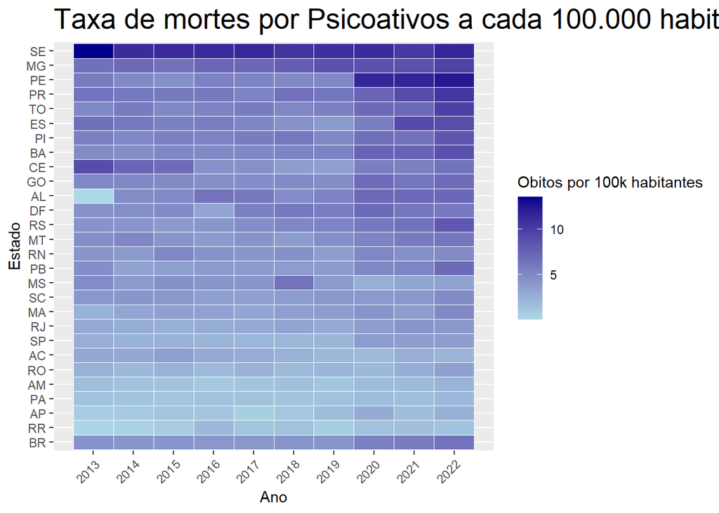

## 6. indicadores

### 6.1. Indicador 1

$$I_1 = \frac{\text{Nº de Óbitos Decorrentes do Uso de Psicoativos no
Espírito Santo}}{\text{Nº de Óbitos Totais no Espírito Santo}} \cdot
1000$$

É possível observar que os números de mortes por uso de substâncias a cada 1000 mortes totais decresceu de 2013 a 2015 e de 2016 a 2019, porém, cresceu entre 2019 e 2021. Este gráfico se assemelha com o gráfico de mortes por psicoativos no Espírito Santo, visto anteriormente.

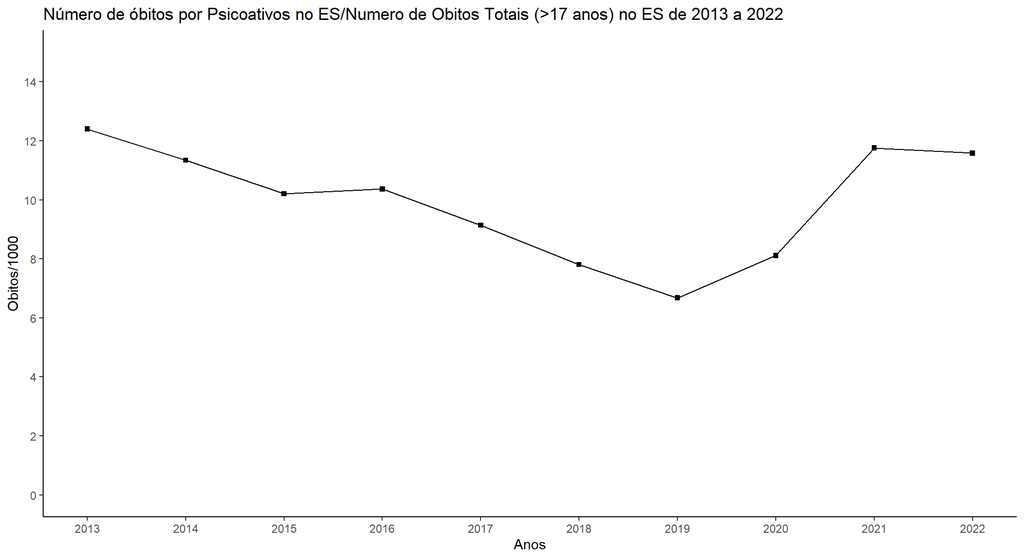

### 6.2. Indicadores 2 e 3

Através deles é possível ver que em termos das mortes totais, o número de mortes no Espírito Santo é bem estável e representa menos de 2% dos óbitos do Brasil. Entretanto, em relação às mortes por psicoativos o estado apresentou um decrescimento principalmente entre os anos de 2016 e 2019 e um crescimento a partir de 2020, representando em torno de 2% a 3% das mortes no Brasil.

$$I_2 = \frac{\text{Nº de Óbitos Decorrentes do Uso de Psicoativos no
Espírito Santo}}{\text{Nº de Óbitos Decorrentes do uso de Psicoativos no
Brasil}} \cdot 100$$

$$I_3 = \frac{\text{Nº de Óbitos Totais no Espírito Santo}}{\text{Nº de
Óbitos Totais no Brasil}}\cdot 100$$

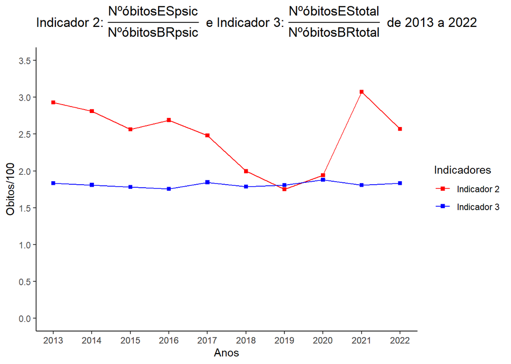

### 6.3. Indicadores 4 e 5

Os indicadores 4 e 5 mostram o número de óbitos por psicoativos em relação a população do Brasil e do Espírito Sant. Através deles é possível compreender que enquanto no Brasil o número de óbitos por psicoativos a cada 100.000 habitante variou de 4 a 6, no Espírito Santo esse número divergiu muito no deccorer dos anos, assumindos valores que vão de aproximadamente 4 a aproximadamente 9 óbitos a cada 100.000 habitantes no estado. Vale ressaltar ainda que o indicador do ES só foi menos que o do Brasil no ano de 2019.

$$I_4 = \frac{\text{Nº de Óbitos Decorrentes do Uso de Psicoativos no
Espírito Santo}}{\text{População Estimada do Espírito Santo no ano
correspondente}} \cdot 100000$$

$$I_5 = \frac{\text{Nº de Óbitos Decorrentes do Uso de Psicoativos no
Brasil}}{\text{População Estimada do Brasil no ano correspondente}}
\cdot 100000$$

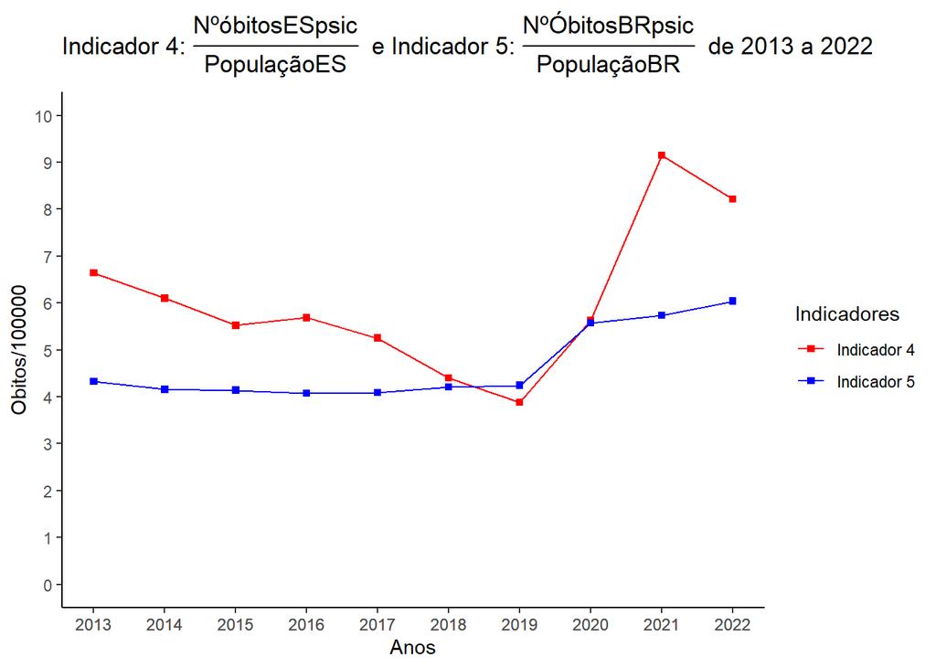

## 7. Outras Possíveis Análises

### 7.1. Divisão do Espírito Santo por Regiões

| Divisão Territorial | Partes |
| --- | --- |
| Regionalização segundo a Lei Complementar 5.120/95 | Metropolitana, Polo Linhares, Metrópole Expandida Sul, Sudeste Serrano, Central Serrana, Litoral norte, Extremo Norte, Polo Colatina, Noroeste 1, Noroeste 2, Polo Cachoeiro, Caparaó |
| Regionalização BANDES | Norte, Sul |
| Regionalização Macro - SESA | Norte, Centro, Sul |
| Regionalização Micro - SESA | Cachoeiro Itapemerim, Colatina, Guaçuí, Linhares, Serra, São Mateus, Vila Velha, Vitoria |
| Regionalização - SECULT | Caparaó, Centro-Norte, Metropolitana, Norte, Serrana, Sul |
| Regionalização - SEDURB | Doce Oeste, Doce Leste, Metropolitana, Litoral Sul, Norte, Sul Serrana |
| Regionalização - SEFAZ | Metropolitana, Nordeste, Noroeste, Sul |
| Regionalização - SETUR | Caparaó, Doce Pontões, Doce Terra Morena, Metropolitana,. Montanhas Capixabas, Pedrão Pao de Mel, Verde e das Águas, Da costa e da Imigração, Dos imigrantes, Dos Vales e do Café |
| Conselhos Regionais de Meio Ambiente - CONREMAS | CONREMA I, CONREMA II, CONREMA III, CONREMA IV, CONREMA V |
| Regionalização Geral - SETADES | Central, Extremo Norte, Extremo Sul, Norte, Serrana, Sul Praiano |
| Regiões | Sul, Centro, Litoral Norte, Noroeste |

### 7.2. Informações sobre as possíveis variáveis

| VARIÁVEL | EXPLICAÇÃO |
| --- | --- |
| ACIDTRAB | Indica se o evento que desencadeou o óbito está relacionado ao processo de trabalho. (1 – sim; 2 – não; 9 – ignorado) |
| ALTCAUSA | Indica se houve correção ou alteração da causa do óbito após investigação. (1- Sim; 2 – Não) |
| ASSISTMED | Se refere ao atendimento médico continuado que o paciente recebeu, ou não, durante a enfermidade que ocasionou o óbito. (1 – sim; 2 – não; 9 – ignorado) |
| ATESTADO | CIDs informados no atestado. (Códigos CID 10) |
| ATESTANTE | Indica se o medico que assina atendeu o paciente 1: Sim 2: Substituto 3: IML 4: SVO 5: Outros |
| BAIRES | Bairro de residencia. Este codigo e atribuido por cada estado e/ou municipio, nao fazendo parte da base nacional |
| CARTORIO | Código do cartório onde o óbito foi registrado |
| CAUSABAS | Causa básica da DO. (Códigos CID 10) |
| CAUSABAS_O | Causa básica informada antes da resseleção. (Códigos CID 10) |
| CAUSAMAT | CID da causa externa associada a uma causa materna. (Códigos CID 10) |
| CB_PRE | Causa básica informada antes da resseleção (localidade). (Código CID 10) |
| CIRCOBITO | Tipo de morte violenta ou circunstâncias em que se deu a morte não natural. (1 – acidente; 2 – suicídio; 3 – homicídio; 4 – outros; 9 – ignorado) |
| CIRURGIA | Realização de cirurgia. (1 – sim; 2 – não; 9 – ignorado) |
| CODBAIOCOR | Código do bairro de ocorrência. |
| CODBAIRES | Código do Bairro de residência |
| CODESTAB | Código do estabelecimento |
| CODIFICADO | Informa se formulario foi codificado. (Se estiver codificado (valor: S) ou não (valor: N)) |
| CODIGO | Codigo do estabelecimento onde ocorreu o obito, se LOCOCOR = 1. Este codigo e atribuido por cada estado e/ou municipio, nao fazendo parte da base nacional |
| CODMUNCART | Código do município do cartório |
| CODMUNNATU | Código do município de naturalidade do falecido.(Números) |
| CODMUNOCOR | Código relativo ao município onde ocorreu o óbito. (Números) |
| CODMUNRES | Código do município de residência. Em caso de óbito fetal, considerar o município de residência da mãe. (Números) |
| COMUNSVOIM | Código do município do SVO ou do IML |
| CRITICA | Dado para controle interno |
| CRM | Número de inscrição do Médico atestante no Conselho Regional de Medicina |
| CRSOCOR | Regional de Saude de ocorrencia. Este codigo e atribuido por cada estado e/ou municipio, nao fazendo parte da base nacional |
| CRSRES | Regional de Saude de residencia. Este codigo e atribuido por cada estado e/ou municipio, nao fazendo parte da base nacional |
| DATANASC | Data do nascimento do falecido. Em caso de óbito fetal as datas de óbito e nascimento deverão ser iguais.(Data no padrão ddmmaaaa) |
| DATAOBIT O | Data em que occoreu o óbito.(Data no padrão ddmmaaaa) |
| DATAREG | Data do recebimento. (Data no padrão ddmmaaaa) |

[output cut: 91 more lines]

## 8. Referências Bibliográficas

SALDANHA, Raphael de Freitas; BASTOS, Ronaldo Rocha; BARCELLOS, Christovam. Microdatasus: pacote para download e pré-processamento de microdados do Departamento de Informática do SUS (DATASUS). Cad. Saúde Pública, Rio de Janeiro , v. 35, n. 9, e00032419, 2019. Available from https://doi.org/10.1590/0102-311x00032419 \

SIM. Sistema de Informação sobre Mortalidade. Departamento de Informática do Sistema Único de Saúde (DATASUS). Registros das declarações de óbito à partir de 1996, tratados e enriquecidos. In: Plataforma de Ciência de Dados aplicada à Saúde (PCDaS). Disponível em: https://pcdas.icict.fiocruz.br. DOI: https://doi.org/10.7303/syn26343262, 2021. \

MEDICINA NET. Classificação Internacional de Doenças (CID-10) - Capítulo F. MedicinaNET. Disponível em: https://www.medicinanet.com.br/cid10/f.htm. Acesso em: 15 jul. 2024.\

INSTITUTO JONES DOS SANTOS NEVES. Nota Técnica 18: Análise Econômica do Estado do Espírito Santo. Vitória: IJSN, 2024. Disponível em: https://ijsn.es.gov.br/Media/IJSN/PublicacoesAnexos/notatecnica/ijsn_nt18.pdf. Acesso em: 15 jul. 2024.